# 1/*f* noise is related to age, but not short-term memory or sensorimotor reaction time.

Jan Freyberg

12/05/2017

Abstract

Recent evidence points towards an increase in 1/*f* neural noise (noise with decreasing power in higher frequency bands) with age. Previous evidence related this increase to a decrease in working memory performance. Here, we attempted to replicate previous findings with data from the Cam-CAN project. We used two minutes of a resting-state recording to estimate the power-spectral density of neural activity. We then correlated the $\mathbf{\beta}$ of a regression of noise on frequency with age, sensorimotor reaction times, and short-term memory performance. We reproduced previously demonstrated increases in 1/*f* noise with age, but did not find a relationship with working memory performance, indicating that it may not be important in cognitive decline in ageing.

# Introduction

One feature of the power spectrum of human brain activity obtained through electrophysiological imaging is a decrease in power with increasing frequency. This relationship between power and the inverse of frequency (often described as 1/*f*, or pink, noise) has recently been linked to ageing (Voytek et al. 2015). Voytek and colleagues found that the linear relationship between frequency and noise was steeper in younger individuals, with less electrophysiological noise in high frequency bands. They were able to show this relationship using both intracranial electrocorticography (ECoG) and electroencephalography (EEG). Voytek and colleagues also demonstrated a relationship between the levels of 1/*f* noise and visual working memory, and that 1/*f* noise mediates impairments of visual working memory in ageing.

Here, we wanted to reproduce the finding and test its central hypoethis of a relationship between in a public dataset: the Cambridge Center for Ageing and Neuroscience data repository (Cam-CAN, Taylor et al. 2017). We therefore tried to replicate the finding of 1/*f* noise increasing in age, as well as the relationship between 1/*f* noise and working memory performance.

# Methods

The Cam-CAN Stage 2 release includes one 8m40s resting-state and one 8m40s sensorimotor task MEG recordings for 647 participants. Resting-state recordings were conducted with eyes closed, and the sensorimotor task required button response to bilateral sine grating and concurrent audio tone presentation. Participants also completed behavioural tasks outside the MEG scanner. Here, we analysed a visual short term memory task: matching a sequence of hues, storing 1 to 4 hues in short-term memory.

MEG recording methods are fully described in Taylor et al. (2017). Out of 647, we analysed 157 resting-state and 371 task recordings. This subset of subjects had an average age of 52.3 years (st.dev.: 18.9, range: 18-88).

All data analysis was performed using `MNE-python` (Gramfort et al. 2014, Gramfort et al. (2013)). We chose a random two-minute segment from the full recording. We performed temporal space-signal separation [tSSS, Taulu, Simola, and Kajola (2005); correlation threshold 0.98; 10-sec sliding window], followed by ICA decomposition and removal of ICA components based on the highest correlation with the HEOG, VEOG and ECG channels. We then computed the log of the power-spectrum from 2 Hz to 7 Hz and from 14 Hz to 24 Hz, avoiding the alpha range (see Voytek et al. 2015), using Welch’s method (2 s sliding window, 50% overlap). We calculated a linear regression of this semi-log data for each gradiometer for each individual and removed any electrodes in which the intercept of this linear regression was two standard-deviations above or below the average for an individual was removed. We performed correlation analyses between the regression slope and age, sensorimotor reaction times and short-term memory.

# Results

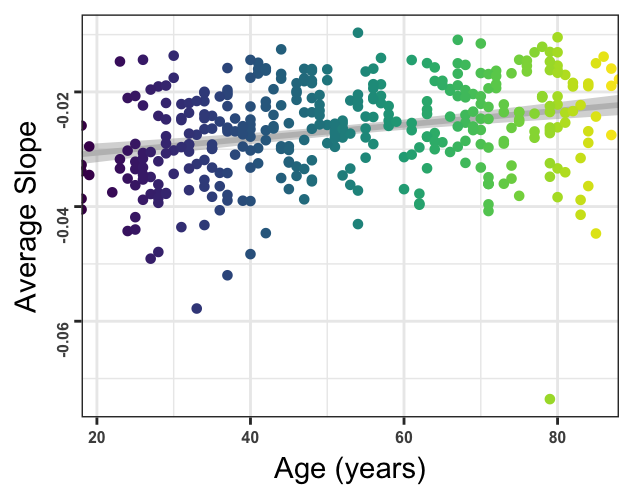

###### *Figure 1: Relationship between 1/f noise during a sensorimotor task and age.*

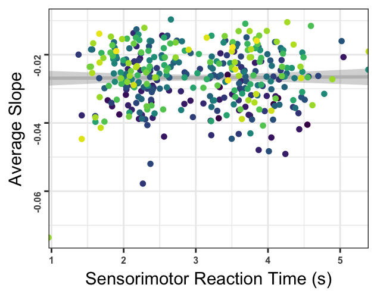

###### *Figure 2: No relationship between 1/f noise and reaction times.*

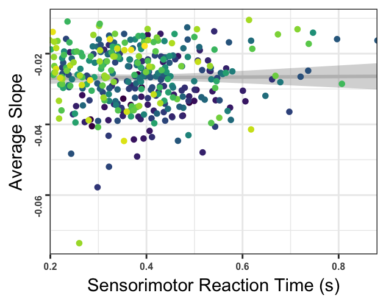

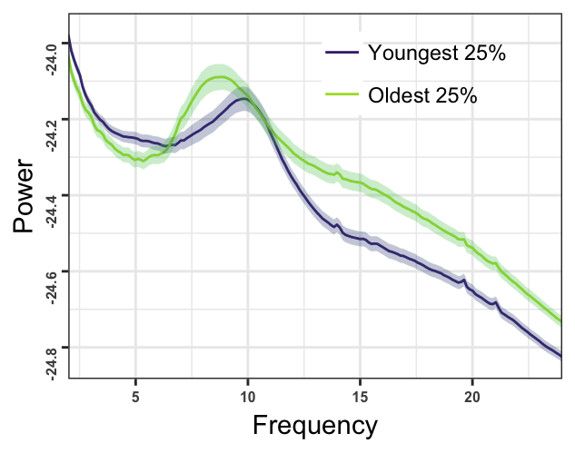

# Conclusions

# References

Gramfort, Alexandre, Martin Luessi, Eric Larson, Denis A. Engemann, Daniel Strohmeier, Christian Brodbeck, Roman Goj, et al. 2013. “MEG and EEG Data Analysis with MNE-Python.” *Frontiers in Neuroscience* 7. doi:10.3389/fnins.2013.00267.

Gramfort, Alexandre, Martin Luessi, Eric Larson, Denis A. Engemann, Daniel Strohmeier, Christian Brodbeck, Lauri Parkkonen, and Matti S. Hämäläinen. 2014. “MNE Software for Processing MEG and EEG Data.” *NeuroImage* 86 (February): 446–60. doi:10.1016/j.neuroimage.2013.10.027.

Podvalny, Ella, Niv Noy, Michal Harel, Stephan Bickel, Gal Chechik, Charles E. Schroeder, Ashesh D. Mehta, Misha Tsodyks, and Rafael Malach. 2015. “A Unifying Principle Underlying the Extracellular Field Potential Spectral Responses in the Human Cortex.” *Journal of Neurophysiology* 114 (1): 505–19. doi:10.1152/jn.00943.2014.

Taulu, S., J. Simola, and M. Kajola. 2005. “Applications of the Signal Space Separation Method.” *IEEE Transactions on Signal Processing* 53 (9): 3359–72. doi:10.1109/TSP.2005.853302.

Taylor, Jason R., Nitin Williams, Rhodri Cusack, Tibor Auer, Meredith A. Shafto, Marie Dixon, Lorraine K. Tyler, Cam-CAN, and Richard N. Henson. 2017. “The Cambridge Centre for Ageing and Neuroscience (Cam-CAN) Data Repository: Structural and Functional MRI, MEG, and Cognitive Data from a Cross-Sectional Adult Lifespan Sample.” *NeuroImage*, Data sharing part ii, 144, Part B (January): 262–69. doi:10.1016/j.neuroimage.2015.09.018.

Voytek, Bradley, Mark A. Kramer, John Case, Kyle Q. Lepage, Zechari R. Tempesta, Robert T. Knight, and Adam Gazzaley. 2015. “Age-Related Changes in 1/F Neural Electrophysiological Noise.” *The Journal of Neuroscience* 35 (38): 13257–65. doi:10.1523/JNEUROSCI.2332-14.2015.